# Is the Phillips Curve dead for all? Estimating PC and NAIRU for subgroups of the labor market.

Pritha Chaudhuri

5/19/2020

## Estimate Aggregate Phillips Curve

Estimate following Phillips Curve similar to CG (2015) and Tillman (2010).
$$\pi_t-\mathbb{E}\pi_{t+1}=\beta_0+\beta_1u_t+\varepsilon_t$$
where inflation expectations is backwards looking assuming adaptive expectations, as in CG (2015)
$$\mathbb{E}\pi_{t+1}=\frac{1}{4}\big(\pi_{t-1}+\pi_{t-2}+\pi_{t-3}+\pi_{t-4} \big)$$
Available measures of inflation and inflation expectations

- Consumer Price Index (CPI), BLS measure
- Personal Consumption Expenditure, BEA measure
- GDP Deflator
- Greenbook forecasts
- FOMC Member forecasts
- Michigan Survey of Consumers, household expectations of inflation

Measure of unemployment

- BLS measure
- Greenbook forecast
- FOMC member forecasts

### CPI, PCE and BLS measure of unemployment: 1990-2019

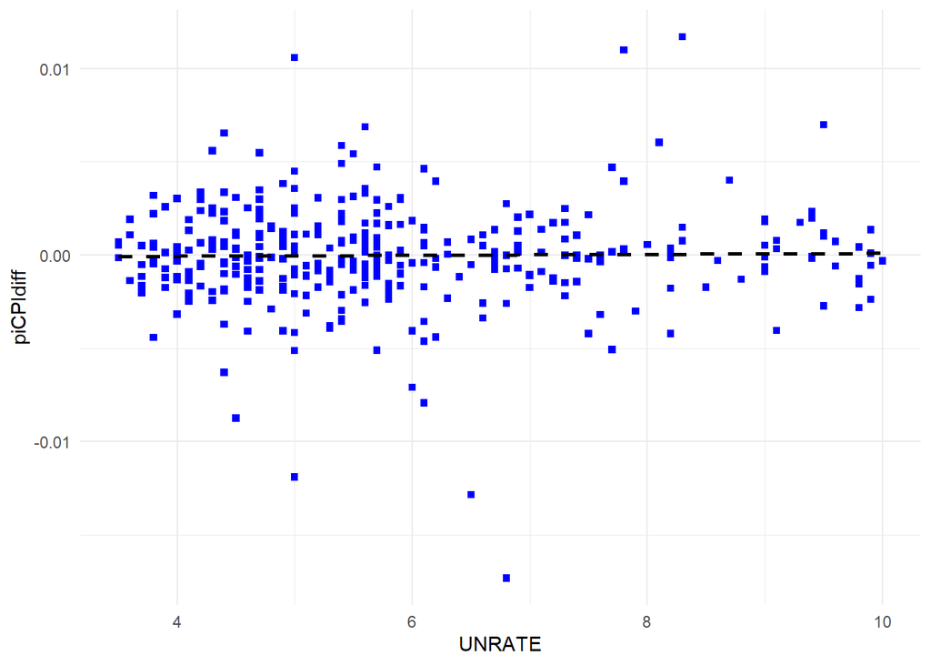

#### Regression result

```
##
## ===========================================================
##                                    Dependent variable:
##                                ----------------------------
##                                  piCPIdiff     piPCEPIdiff
##                                     (1)            (2)
## -----------------------------------------------------------
## UNRATE                            0.00003        0.00002
##                                   (0.0001)      (0.0001)
##
## Constant                          -0.0002        -0.0001
##                                   (0.001)       (0.0004)
##
## -----------------------------------------------------------
## Observations                        360            360
## R2                                 0.0002        0.0004
## Adjusted R2                        -0.003        -0.002
## Residual Std. Error (df = 358)     0.003          0.002
## F Statistic (df = 1; 358)          0.080          0.126
## ===========================================================
## Note:                           *p<0.1; **p<0.05; ***p<0.01
```

#### NAIRU estimate

```
## (Intercept)
##    6.179023
```

Greenbook projections are made available to the FOMC before each meeting. The Fed research staff makes projections of how the economy will fare in the future. The data is made available to the public with a 5 year lag. Most current year of data is 2013. Estimate the following equation
$$\pi_t-\mathbb{E}\pi_{t+1}=\beta_0+\beta_1u_t+\varepsilon_t$$
where

- $\pi_t=gPCPIXF0$: core CPI inflation projection for current quarter (t).
- $\mathbb{E}\pi_{t+1}=gPCPIXB1$: core CPI inflation historical value for previous quarter (t-1), assuming adaptive expectations.
- $u_t=UNEMPF0$: unemployment rate projection for current quarter (t).

##### 1990-1997

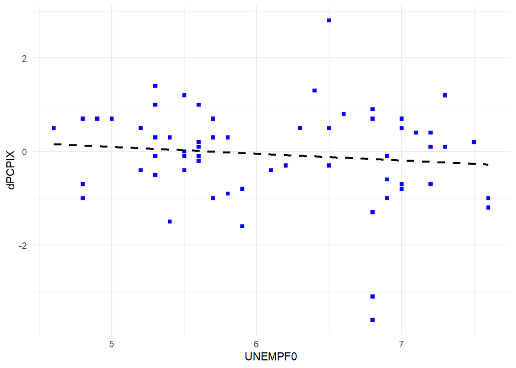

##### 1998-2005

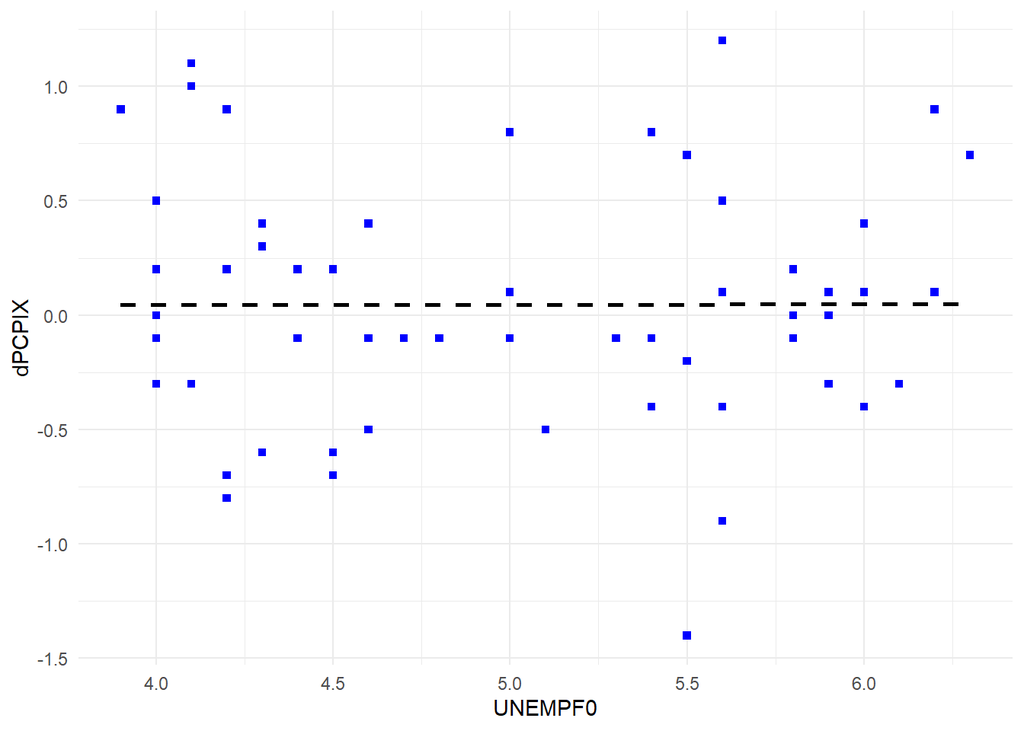

##### 2006-2013

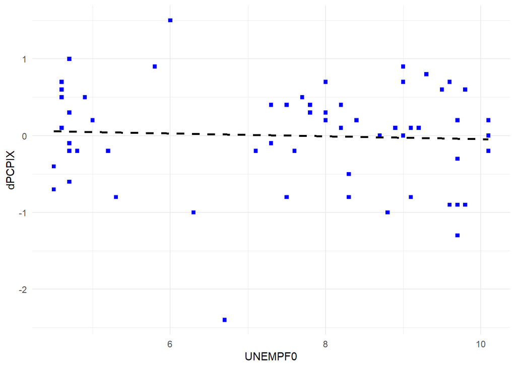

##### Regression results

```
##
## ===========================================================
##                                    Dependent variable:
##                               -----------------------------
##                                          dPCPIX
##                                  (1)       (2)       (3)
## -----------------------------------------------------------
## UNEMPF0                        -0.145     0.001    -0.018
##                                (0.155)   (0.088)   (0.042)
##
## Constant                        0.824     0.043     0.140
##                                (0.951)   (0.448)   (0.320)
##
## -----------------------------------------------------------
## Observations                     64        64        64
## R2                              0.014    0.00000    0.003
## Adjusted R2                    -0.002    -0.016    -0.013
## Residual Std. Error (df = 62)   1.015     0.529     0.667
## F Statistic (df = 1; 62)        0.877    0.0001     0.191
## ===========================================================
## Note:                           *p<0.1; **p<0.05; ***p<0.01
```

1. 1990-1997 sample
2. 1998-2005 sample.
3. 2006-2013 sample.

Slope and intercept insignificant for all samples.

##### NAIRU estimate

```
## [1]   5.688437 -54.110989   7.597374
```

### FOMC member forecasts: Similar to Tillmann (2010)

FOMC member forecasts are released with the Monetary Policy Report, made twice a year in February and July. These forecasts are made by the 12 regional Federal Reserve Bank presidents and the members of the Board fo Governors excluding the Chairman. These forecasts are released by the Philadelphia Fed with a 10 year lag, so only forecasts up till 2007 is available. For the estimation exercise I use forecasts made at the July meetings for each year. Estimate the following equation
$$\pi_{t+5|t}-\pi_{t+1|t}=\beta_0+\beta_1u_{t+1|t}+\varepsilon_t$$
where

- $t$ is July meeting (Q3) of that year.
- $\pi_{t+5|t}$ is inflation forecast made in July meeting for Q4 of following year.
- $\pi_{t+1|t}$ is inflation forecast made in July meeting for Q4 for current year.
- $u_{t+1|t}$ is unemployment forecast made in Juy meeting for Q4 of current year.

Note that the above specification of the Phillips curve assumes adaptive expectations, where expected inflation is backward looking. In an alternative specification Tillmann (2010) uses $u_{t+5|t}$ instead of $u_{t+1|t}$.

##### 1992-1998

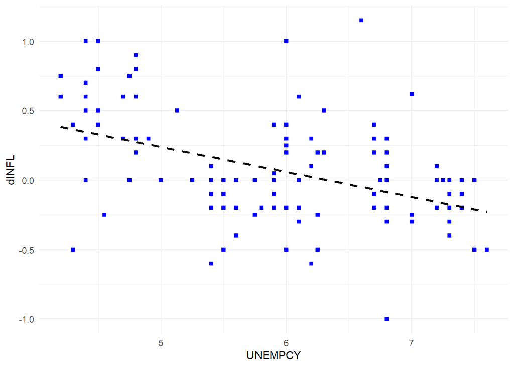

##### 1999-2007

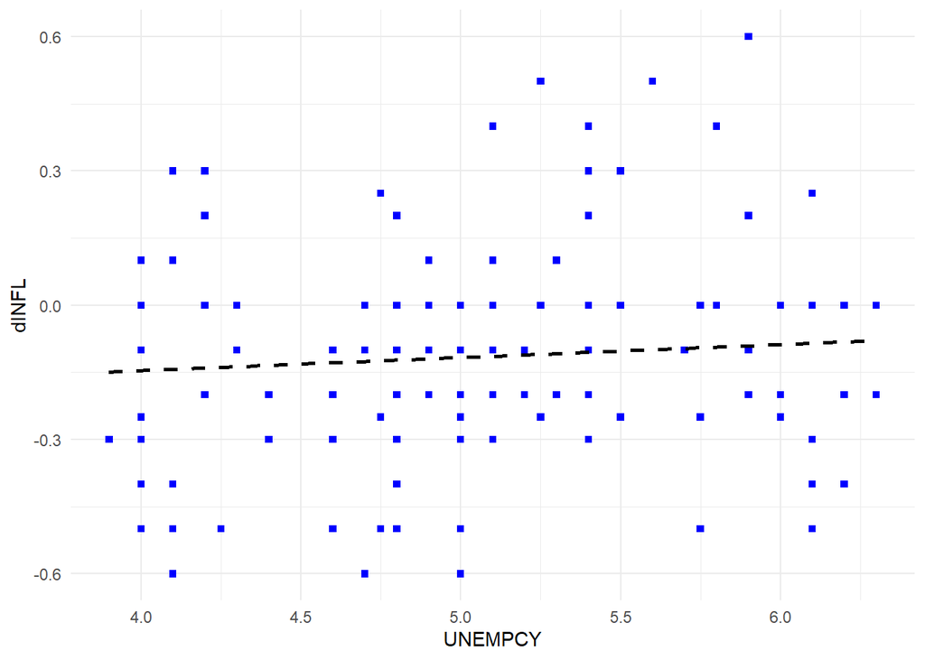

##### 1992-2007

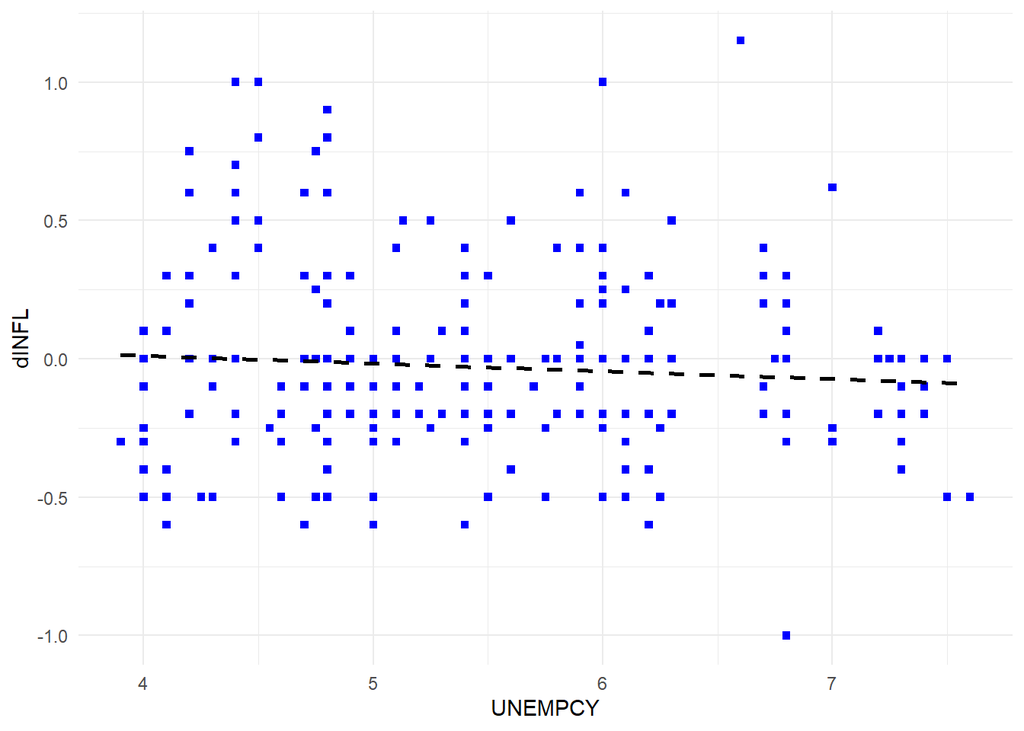

##### Regression results

```
##
## ===================================================================================
##                                           Dependent variable:
##                     ---------------------------------------------------------------
##                                                  dINFL
##                               (1)                   (2)                 (3)
## -----------------------------------------------------------------------------------
## UNEMPCY                    -0.180***               0.029              -0.028
##                             (0.035)               (0.030)             (0.022)
##
## Constant                   1.142***               -0.263*              0.124
##                             (0.206)               (0.151)             (0.123)
##
## -----------------------------------------------------------------------------------
## Observations                  120                   150                 270
## R2                           0.187                 0.006               0.006
## Adjusted R2                  0.180                -0.0003              0.002
## Residual Std. Error    0.361 (df = 118)      0.244 (df = 148)    0.336 (df = 268)
## F Statistic         27.168*** (df = 1; 118) 0.960 (df = 1; 148) 1.579 (df = 1; 268)
## ===================================================================================
## Note:                                                   *p<0.1; **p<0.05; ***p<0.01
```

1. 1992-1998 sample.
2. 1999-2007 sample.
3. 1992-2007 sample.

Significance of slope and intercept goes away as sample increases.

##### NAIRU estimate

```
## [1] 6.329302 9.000107 4.415132
```

## Estimate Disaggregate Phillips Curve

Above exercise so far has been considering the entire economy and the aggregate unemployment rate. But what about different subgroups of the labor market? Will the Phillips curve relationship hold for one subgroup and not for the other? Different subgroups that can be considered are

- Education: high-skill vs low-skill
- Gender: male vs female
- Race: White vs Black
- Age: Young vs Old

### Education Levels

Data obtained from BLS for four categories

1. Bachelor’s degree or higher
2. Some college or Associate’s degree
3. High-school graduates, no college
4. Less than high-school diploma

Estimate the following equation for each group
$$\pi_t-\mathbb{E}\pi_{t+1}=\beta_0+\beta_1u^s_t+\varepsilon_t$$
where $s$ denotes one of the four subgroups above.

#### Using Greenbook inflation forecast

```
##
## ============================================================================================================
##                                                    Dependent variable:
##              -----------------------------------------------------------------------------------------------
##                                                          dPCPIX
##                (1)     (2)     (3)     (4)     (5)     (6)     (7)     (8)     (9)    (10)    (11)    (12)
## ------------------------------------------------------------------------------------------------------------
## Bachelors    -0.092   0.006  -0.055
##              (0.232) (0.123) (0.077)
##
## Somecoll                             -0.090   0.016  -0.012
##                                      (0.114) (0.081) (0.043)
##
## Highschool                                                   -0.096   0.011  -0.018
##                                                              (0.098) (0.088) (0.036)
##
## Lesshs                                                                               -0.082   0.009  -0.008
##                                                                                      (0.073) (0.072) (0.026)
##
## Constant      0.264   0.033   0.197   0.423  -0.010   0.078   0.541  -0.004   0.141   0.821  -0.022   0.092
##              (0.600) (0.293) (0.281) (0.510) (0.304) (0.280) (0.533) (0.397) (0.280) (0.707) (0.547) (0.305)
##
## ------------------------------------------------------------------------------------------------------------
## Observations   48      64      64      48      64      64      48      64      64      48      64      64
## ============================================================================================================
## Note:                                                                            *p<0.1; **p<0.05; ***p<0.01
```

#### Using FOMC member forecasts

```
##
## =========================================================================================================================
##                                                          Dependent variable:
##              ------------------------------------------------------------------------------------------------------------
##                                                                 dINFL
##                 (1)       (2)      (3)      (4)      (5)     (6)      (7)       (8)      (9)     (10)      (11)    (12)
## -------------------------------------------------------------------------------------------------------------------------
## Bachelors    -0.333***  0.089**  -0.055
##               (0.078)   (0.042)  (0.044)
##
## Somecoll                                 -0.158***  0.016  -0.039*
##                                           (0.035)  (0.025) (0.022)
##
## Highschool                                                         -0.138***  0.052**  -0.002
##                                                                     (0.038)   (0.025)  (0.023)
##
## Lesshs                                                                                         -0.103***  0.028    0.003
##                                                                                                 (0.023)  (0.020)  (0.013)
##
## Constant     0.903***  -0.326***  0.104  0.746***  -0.174*  0.125  0.792***  -0.351*** -0.016  1.047***  -0.323** -0.049
##               (0.194)   (0.099)  (0.108)  (0.152)  (0.094) (0.089)  (0.198)   (0.116)  (0.111)  (0.214)  (0.150)  (0.111)
##
## -------------------------------------------------------------------------------------------------------------------------
## Observations    120       150      270      120      150     270      120       150      270      120      150      270
## =========================================================================================================================
## Note:                                                                                         *p<0.1; **p<0.05; ***p<0.01
```

### Gender

Data obtained from FRED. 2 categories

1. Male
2. Female

Estimate same equation as education levels. Here $s$ either male or female.

#### Regression results

```
##
## ===================================================================
##                               Dependent variable:
##              ------------------------------------------------------
##                                      dINFL
##                 (1)      (2)      (3)      (4)       (5)      (6)
## -------------------------------------------------------------------
## Men          -0.118***  0.036   -0.005
##               (0.030)  (0.022)  (0.018)
##
## Women                                   -0.181***  0.066**  -0.003
##                                          (0.039)   (0.031)  (0.024)
##
## Constant     0.794***  -0.296** -0.001  1.137***  -0.441*** -0.013
##               (0.183)  (0.115)  (0.102)  (0.228)   (0.155)  (0.128)
##
## -------------------------------------------------------------------
## Observations    120      150      270      120       150      270
## R2             0.117    0.017   0.0003    0.156     0.029   0.00005
## ===================================================================
## Note:                                   *p<0.1; **p<0.05; ***p<0.01
```

Sample periods for (1)-(3) and (4)-(6) same as FOMC member forecast regressions.

For 1992-1998 sample, slope coefficient is highly significant for Men and Women. Both coefficients are negative and shows Women have a larger slope than Men, meaning their PC is steeper. For 1999-2007 sample, Women have a significant and positive slope.

#### Nairu estimates

```
##      period gender      nairu
## 1 1992-1998    Men  6.7546422
## 2 1999-2007    Men  8.3299193
## 3 1992-2007    Men -0.2328237
## 4 1992-1998  Women  6.2643447
## 5 1999-2007  Women  6.6775654
## 6 1992-2007  Women -5.0514356
```

### Race

Data obtained from FRED. 3 categories

1. White
2. Black or African-American
3. Hispanic or Latino

Estimate same equation as education levels. Here $s$ White, Black or Hispanic

#### Regression result

```
##
## ===============================================================================================
##                                             Dependent variable:
##              ----------------------------------------------------------------------------------
##                                                    dINFL
##                 (1)       (2)      (3)      (4)      (5)     (6)      (7)       (8)      (9)
## -----------------------------------------------------------------------------------------------
## White        -0.152***  0.055*   -0.014
##               (0.036)   (0.030)  (0.023)
##
## Black                                    -0.090***  0.017   0.001
##                                           (0.021)  (0.016) (0.012)
##
## Hispanic                                                           -0.094***  0.050**  0.023**
##                                                                     (0.024)   (0.020)  (0.011)
##
## Constant     0.866***  -0.358***  0.039  1.094***  -0.275* -0.039  0.969***  -0.435*** -0.206**
##               (0.188)   (0.134)  (0.112)  (0.235)  (0.147) (0.121)  (0.225)   (0.131)  (0.085)
##
## -----------------------------------------------------------------------------------------------
## Observations    120       150      270      120      150     270      120       150      270
## R2             0.132     0.022    0.001    0.138    0.008  0.00004   0.119     0.039    0.017
## ===============================================================================================
## Note:                                                               *p<0.1; **p<0.05; ***p<0.01
```

For 1992-1998 sample, all three races have highly significant slope coefficient. Slope is negative. Slope is steeper for White, then Hispanic and lastly Black. For 1999-2007 sample, White and Hispanic have a positive and significant coefficient. For 1992-2007 sample, only Hispanic population have a significant coefficient.

#### Nairu estimate

```
##      period     race     nairu
## 1 1992-1998    White  5.684999
## 2 1999-2007    White  6.496632
## 3 1992-2007    White  2.781905
## 4 1992-1998    Black 12.208027
## 5 1999-2007    Black 16.158520
## 6 1992-2007    Black 34.136209
## 7 1992-1998 Hispanic 10.269341
## 8 1999-2007 Hispanic  8.742510
## 9 1992-2007 Hispanic  8.918586
```